© Bản quyền thuộc về Quantopian Inc.  
© Bản quyền sửa đổi thuộc về AI Cafe¹  
Giấy phép [Creative Commons Attribution 4.0](https://creativecommons.org/licenses/by/4.0/legalcode).  
[Khuyến cáo](https://aicafe.one/khuyen-cao/)

# Phòng vệ Beta (Beta Hedging)

By Evgenia "Jenny" Nitishinskaya and Delaney Granizo-Mackenzie with example algorithms by David Edwards

Edited by AI Cafe¹

## Mô hình các nhân tố

Mô hình các nhân tố là một cách giải thích lợi nhuận của một tài sản thông qua một tổ hợp tuyến tính của lợi nhuận của các tài sản khác. Dạng tổng quát của một mô hình các nhân tố là

$$Y = \alpha + \beta_1 X_1 + \beta_2 X_2 + \dots + \beta_n X_n$$

Điều này có vẻ quen thuộc, vì nó chính xác là mô hình mà hồi quy tuyến tính. Các $X$ cũng có thể là chỉ số thay vì tài sản. Một ví dụ có thể là ước lượng của một nhà phân tích.

## Beta là gì?

Beta của một tài sản đối với một tài sản khác chỉ đơn giản là $\beta$ từ mô hình ở trên. Ví dụ, nếu chúng ta hồi quy FPT so với VNINDEX sử dụng mô hình $Y_{FPT} = \alpha + \beta X$, thì beta của FPT đối với VNINDEX sẽ là beta đó. Nếu chúng ta sử dụng mô hình $Y_{FPT} = \alpha + \beta X_{VNINDEX} + \beta X_{VCB}$, thì bây giờ chúng ta có hai beta, một là mức độ tiếp xúc của FPT với VNINDEX và một là mức độ tiếp xúc của FPT với VCB.

Thường thì "beta" sẽ đề cập đến mức độ tiếp xúc beta của một cổ phiếu với VNINDEX. Chúng tôi sẽ sử dụng nó với ý nghĩa đó trừ khi có chỉ định khác.

```python
# Import libraries
import numpy as np
from statsmodels import regression
import statsmodels.api as sm
import matplotlib.pyplot as plt
```

```python
# Cài thư viện lấy dữ liệu miễn phí
!curl -fsSLO https://raw.githubusercontent.com/algo-stocks/data/master/data.py
```

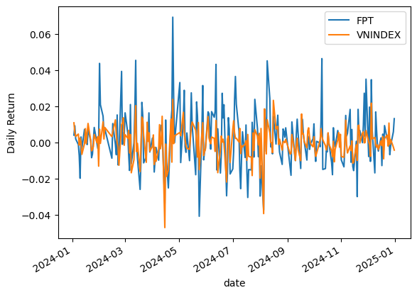

```python
from data import get_prices

start = '2024-01-01'
end = '2025-01-01'

prices = get_prices('FPT', 'VNINDEX', start_date=start, end_date=end).dropna()

asset = prices.FPT
benchmark = prices.VNINDEX


# We have to take the percent changes to get to returns
# Get rid of the first (0th) element because it is NAN
r_a = asset.pct_change()[1:]
r_b = benchmark.pct_change()[1:]

# Let's plot them just for fun
r_a.plot()
r_b.plot()
plt.ylabel("Daily Return")
plt.legend();
```

Bây giờ chúng ta có thể thực hiện hồi quy để tìm $\alpha$ và $\beta$:

```python
# Let's define everything in familiar regression terms
X = r_b.values # Get just the values, ignore the timestamps
Y = r_a.values

def linreg(x,y):
    # We add a constant so that we can also fit an intercept (alpha) to the model
    # This just adds a column of 1s to our data
    x = sm.add_constant(x)
    model = regression.linear_model.OLS(y,x).fit()
    # Remove the constant now that we're done
    x = x[:, 1]
    return model.params[0], model.params[1]

alpha, beta = linreg(X,Y)
print('alpha: ' + str(alpha))
print('beta: ' + str(beta))
```

```
alpha: 0.0020881643384164693
beta: 1.061388094512692
```

Nếu chúng ta vẽ đường thẳng $\alpha + \beta X$, chúng ta có thể thấy rằng nó thực sự giống như đường thẳng tốt nhất:

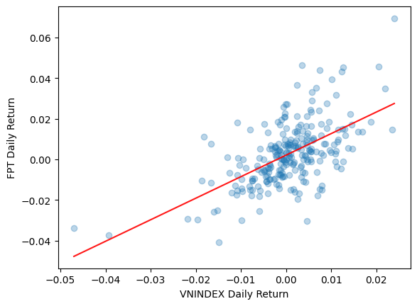

```python
X2 = np.linspace(X.min(), X.max(), 100)
Y_hat = X2 * beta + alpha

plt.scatter(X, Y, alpha=0.3) # Plot the raw data
plt.xlabel("VNINDEX Daily Return")
plt.ylabel("FPT Daily Return")

 # Add the regression line, colored in red
plt.plot(X2, Y_hat, 'r', alpha=0.9);
```

## Rủi Ro

Nói chung, beta này liên quan đến khái niệm về mức độ rủi ro mà bạn chấp nhận khi nắm giữ một tài sản. Nếu một tài sản có độ nhạy beta cao đối với VNINDEX, thì trong khi nó sẽ hoạt động rất tốt khi thị trường tăng, nó sẽ hoạt động rất kém khi thị trường giảm. Beta cao tương ứng với rủi ro đầu cơ cao. Bạn đang thực hiện một lần cược có tính biến động lớn hơn.

Nhiều nhà đầu tư tổ chức đánh giá cao các chiến lược có độ nhạy beta không đáng kể đối với nhiều yếu tố càng tốt. Điều này có nghĩa là tất cả các khoản lợi nhuận trong một chiến lược nằm trong phần $\alpha$ của mô hình và độc lập với các yếu tố khác. Điều này rất được mong đợi, vì nó có nghĩa là chiến lược này không phụ thuộc vào điều kiện thị trường. Nó sẽ kiếm tiền tốt như nhau trong một cuộc khủng hoảng cũng như trong một thị trường tăng trưởng. Những chiến lược này là những chiến lược hấp dẫn nhất đối với những cá nhân có quỹ tiền lớn như quỹ từ thiện và quỹ tài sản quốc gia.

## Quản lý Rủi Ro

Quá trình giảm thiểu sự tiếp xúc với các yếu tố khác được gọi là quản lý rủi ro. Phòng ngừa rủi ro là một trong những cách tốt nhất để thực hiện quản lý rủi ro trong thực tế.

### Phòng vệ rủi ro

Nếu chúng ta xác định rằng lợi nhuận của danh mục đầu tư phụ thuộc vào thị trường thông qua mối quan hệ này

$$Y_{danh mục} = \alpha + \beta X_{VNINDEX}$$

thì chúng ta có thể mở một vị thế bán khống trong VNINDEX để cố gắng loại bỏ rủi ro này. Số lượng chúng ta mở ra là $-\beta V$ trong đó $V$ là tổng giá trị của danh mục đầu tư của chúng ta. Điều này có hiệu quả vì nếu lợi nhuận của chúng ta được xấp xỉ bởi $\alpha + \beta X_{VNINDEX}$, thì việc thêm một vị thế bán khống trong VNINDEX sẽ làm cho lợi nhuận mới của chúng ta trở thành $\alpha + \beta X_{VNINDEX} - \beta X_{VNINDEX} = \alpha$. Lợi nhuận của chúng ta giờ đây hoàn toàn là alpha, điều này không phụ thuộc vào VNINDEX và sẽ không bị ảnh hưởng bởi rủi ro từ thị trường.

### Trung Lập với Thị Trường

Khi một chiến lược thể hiện beta ổn định là 0, chúng ta nói rằng chiến lược này là trung lập với thị trường.

### Vấn Đề Với Việc Ước Tính

Vấn đề ở đây là beta mà chúng ta ước tính không nhất thiết sẽ giữ nguyên khi thời gian trôi qua. Do đó, số lượng vị thế bán mà chúng ta đã thực hiện trong VNINDEX có thể không hoàn toàn bảo hiểm cho danh mục đầu tư của chúng ta, và trên thực tế, việc giảm beta một cách đáng kể là khá khó khăn.

Chúng ta sẽ nói nhiều hơn về các vấn đề liên quan đến việc ước tính các tham số trong các bài giảng sau. Ngắn gọn, mỗi ước tính đều có một sai số chuẩn tương ứng với độ ổn định của ước tính trong dữ liệu quan sát.

## Thực hiện bảo hiểm rủi ro

Bây giờ chúng ta đã biết cần bảo hiểm bao nhiêu, hãy xem nó ảnh hưởng đến lợi nhuận của chúng ta như thế nào. Chúng ta sẽ xây dựng danh mục đầu tư của mình bằng cách sử dụng tài sản và chỉ số tham chiếu, cân nhắc chỉ số tham chiếu với trọng số $-\beta$ (âm vì chúng ta đang bán khống nó).

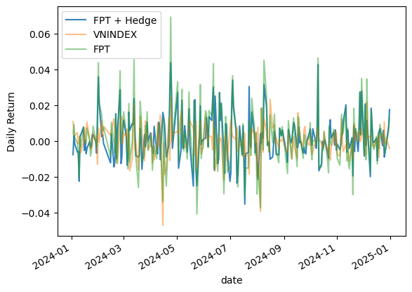

```python
# Construct a portfolio with beta hedging
portfolio = -1*beta*r_b + r_a
portfolio.name = "FPT + Hedge"

# Plot the returns of the portfolio as well as the asset by itself
portfolio.plot(alpha=0.9)
r_b.plot(alpha=0.5);
r_a.plot(alpha=0.5);
plt.ylabel("Daily Return")
plt.legend();
```

Có vẻ như lợi suất danh mục đầu tư theo sát tài sản một cách tương đối chặt chẽ. Chúng ta có thể định lượng sự khác biệt trong hiệu suất của chúng bằng cách tính toán lợi suất trung bình và độ biến động (độ lệch chuẩn của lợi suất) cho cả hai.

```python
print("means: ", portfolio.mean(), r_a.mean())
print("volatilities: ", portfolio.std(), r_a.std())
```

```
means:  0.0020881643384164693 0.0026097443924761425
volatilities:  0.012418456938817705 0.015389106107627228
```

Chúng ta đã giảm sự biến động với một chút tổn thất về lợi nhuận. Hãy kiểm tra xem alpha có giống như trước không, trong khi beta đã được loại bỏ.

```python
P = portfolio.values
alpha, beta = linreg(X,P)
print('alpha: ' + str(alpha))
print('beta: ' + str(beta))
```

```
alpha: 0.0020881643384164693
beta: 9.575673587391975e-16
```

Lưu ý rằng chúng tôi đã phát triển chiến lược phòng ngừa rủi ro của mình dựa trên dữ liệu lịch sử. Chúng tôi có thể kiểm tra xem nó vẫn còn hợp lệ ngoài mẫu bằng cách kiểm tra các giá trị alpha và beta của tài sản và danh mục đầu tư đã được phòng ngừa trong một khung thời gian khác:

```
Asset Historical Estimate:
alpha:0.0020881643384164693
beta:1.061388094512692
Asset Out of Sample Estimate:
alpha: -0.004774210537331979
beta: 1.2576611069972974
Portfolio Out of Sample:
alpha:-0.004774210537331978
beta:0.1962730124846055
```

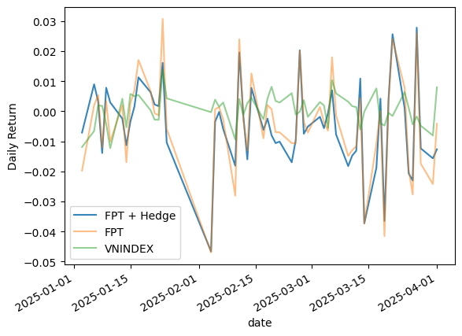

```python
start = '2024-01-01'
end = '2025-01-01'

prices = get_prices('FPT', 'VNINDEX', start_date=start, end_date=end).dropna()

asset = prices.FPT
benchmark = prices.VNINDEX

r_a = asset.pct_change()[1:]
r_b = benchmark.pct_change()[1:]
X = r_b.values
Y = r_a.values
historical_alpha, historical_beta = linreg(X,Y)
print('Asset Historical Estimate:')
print('alpha:' + str(historical_alpha))
print('beta:' + str(historical_beta))

start = '2025-01-01'
end = '2025-04-01'

prices = get_prices('FPT', 'VNINDEX', start_date=start, end_date=end).dropna()

asset = prices.FPT
benchmark = prices.VNINDEX

# Repeat the process from before to compute alpha and beta for the asset
r_a = asset.pct_change()[1:]
r_b = benchmark.pct_change()[1:]
X = r_b.values
Y = r_a.values
alpha, beta = linreg(X,Y)
print('Asset Out of Sample Estimate:')
print('alpha: ' + str(alpha))
print('beta: ' + str(beta))

# Create hedged portfolio and compute alpha and beta
portfolio = -1*historical_beta*r_b + r_a
P = portfolio.values
alpha, beta = linreg(X,P)
print('Portfolio Out of Sample:')
print('alpha:' + str(alpha))
print('beta:' + str(beta))


# Plot the returns of the portfolio as well as the asset by itself
portfolio.name = "FPT + Hedge"
portfolio.plot(alpha=0.9)
r_a.plot(alpha=0.5);
r_b.plot(alpha=0.5)
plt.ylabel("Daily Return")
plt.legend();
```

Như chúng ta thấy, ước lượng beta thay đổi khá nhiều khi chúng ta xem xét ước lượng ngoài mẫu.

## Sự đánh đổi giữa alpha và beta

Việc phòng ngừa rủi ro so với một chỉ số như thị trường thực sự sẽ giảm lợi nhuận của bạn khi thị trường không gặp khó khăn. Tuy nhiên, điều này hoàn toàn ổn. Nếu thuật toán của bạn ít biến động hơn, bạn sẽ có thể sử dụng đòn bẩy trong chiến lược của mình và nhân lợi nhuận về lại mức ban đầu. Còn tốt hơn, lợi nhuận của bạn sẽ ổn định hơn nhiều so với chiến lược beta biến động ban đầu.

Nói chung, mặc dù các chiến lược beta cao thường có vẻ hấp dẫn do lợi nhuận cực kỳ tốt trong các giai đoạn tăng trưởng của thị trường, nhưng chúng sẽ thất bại trong dài hạn vì sẽ phải chịu tổn thất lớn trong thời kỳ suy thoái.

## Các loại phòng vệ khác

Mặc dù chúng tôi sẽ không thực hiện chúng ở đây, nhưng có những chiến lược phòng vệ có thể phù hợp hơn cho các phương pháp đầu tư khác.

### Giao dịch cặp

Một trong số đó là giao dịch cặp, trong đó một tài sản thứ hai được sử dụng thay cho chỉ số chuẩn ở đây. Điều này sẽ cho phép bạn, chẳng hạn, loại bỏ sự biến động trong một ngành bằng cách mua cổ phiếu của một công ty và bán khống cổ phiếu của một công ty khác trong cùng ngành.

### Danh mục cổ phiếu Long-Short

Trong trường hợp này, chúng ta xác định một bảng xếp hạng trên một nhóm $n$ cổ phiếu, sau đó mua dài $p\%$ cổ phiếu hàng đầu và bán khống $p\%$ cổ phiếu dưới cùng với lượng tiền bằng nhau. Điều này có ưu điểm là được phòng ngừa một cách ngầm, so với rõ ràng, khi $n$ lớn. Để thấy lý do tại sao điều này đúng, hãy tưởng tượng việc mua một bộ 100 chứng khoán ngẫu nhiên. Xác suất rằng hệ số beta tiếp xúc thị trường của 100 chứng khoán này xa 1.0 là rất thấp, vì chúng ta đã lấy một mẫu lớn từ thị trường. Tương tự, khi chúng ta xếp hạng theo một chỉ số độc lập nào đó và mua 100 cổ phiếu hàng đầu, xác suất rằng chúng ta chọn các chứng khoán có beta tổng thể xa 1.0 là thấp. Do đó, khi chọn 100 cổ phiếu Long và 100 cổ phiếu Short, beta của chiến lược này trở nên rất gần 1 - 1 = 0. Rõ ràng là một số hệ thống xếp hạng sẽ tạo ra thiên lệch mẫu và phá vỡ giả định này, ví dụ xếp hạng theo beta ước tính của cổ phiếu.

Một lợi thế khác của các chiến lược cổ phiếu Long-Short là bạn đang đặt cược vào bảng xếp hạng, hay nói cách khác là sự khác biệt trong hiệu suất giữa các cổ phiếu xếp hạng cao và thấp. Điều này có nghĩa là bạn không cần phải lo lắng về sự đánh đổi alpha/beta gặp phải trong phòng vệ rủi ro.

*Lưu ý: Tài liệu này mang tính chất chia sẻ kiến thức khoa học dữ liệu. Các mã chứng khoán xuất hiện trong tài liệu chỉ mang tính chất minh hoạ, không khuyến nghị đầu tư. Chúng tôi không chịu trách nhiệm trước mọi rủi ro nào do sử dụng tài liệu này.*